# 1.2-ngaqua-initialized-runs

```python
%matplotlib inline
```

```python
true_path = "/Users/noah/workspace/research/uw-machine-learning/data/raw/2/NG_5120x2560x34_4km_10s_QOBS_EQX/coarse/"
```

```python
import re

def open_caseid(caseid):
    out_3d_path = "/Users/noah/workspace/models/SAMUWgh/OUT_3D"
    out_2d_path = "/Users/noah/workspace/models/SAMUWgh/OUT_2D"

    d3 = xr.open_mfdataset(f"{out_3d_path}/{caseid}_*.nc", autoclose=True)
    d2 = xr.open_mfdataset(f"{out_2d_path}/{caseid}_*.nc")

    return d2, d3


def open_caseid_3d(caseid):
    out_3d_path = "/Users/noah/workspace/models/SAMUWgh/OUT_3D"
    ds = xr.open_mfdataset(f"{out_3d_path}/{caseid}_*.nc", autoclose=True)
    return ds


def swap_z_for_pres(ds):
    ds['p'] = ds.p[0].drop('time')
    return ds.swap_dims({'z': 'p'})


def list_caseids():
    """List the available caseids"""
    ncs = !ls ../OUT_3D/*.nc
    pat = re.compile("^../OUT_3D/(.*?)_\d_\d+.nc$")
    return set(pat.search(nc).group(1) for nc in ncs)


def plot_zonal_velocity(mean):
    im = plt.contourf(mean.y, mean.p, mean,
                      levels=np.r_[-40:45:5], cmap='RdBu_r',
                      extend='both')


    plt.contour(mean.y, mean.p, mean, levels=[-10, -8,-6,-4,-2,0], colors='k')
    plt.ylim([1000,10])
    plt.colorbar(im)
    plt.title("Zonal Velocity")
    plt.xlabel("y")
    plt.ylabel("p");
```

```python
list_caseids()
```

```
{'HeldSuarez_deleteme',
 'HeldSuarez_dt120',
 'NGAqua_dt30.noPhys',
 'NGAqua_icStag.SGS.MICRO.RAD.dt30',
 'NGAqua_icStag.SGS.dt30',
 'NGAqua_icStag.dt30',
 'NGAqua_ngaqua.dt15.QOBS',
 'NGAqua_ngaqua.dt30',
 'NGAqua_test.ic',
 'NGAqua_test.ic.staggered'}
```

```python
d2, d3 = open_caseid("NGAqua_ngaqua.dt30")
```

# Climate

```python
mean = swap_z_for_pres(d3).mean(['time', 'x'])
```

```
Text(0,0.5,'p')
```

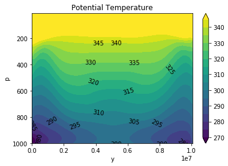

```python
p = mean.p
tm = mean.TABS

tht  = tm * (1000/p)**(2/7)

levels = np.r_[270:350:5]
im = tht.plot.contourf(x='y', y='p', levels=levels, extend='both')
plt.clabel(im, colors='black', inline=False, fmt="%.0f")
plt.ylim([1000, 10])
plt.title("Potential Temperature")
plt.xlabel("y")
plt.ylabel("p")
# tht.plot.contourf(levels=levels)
```

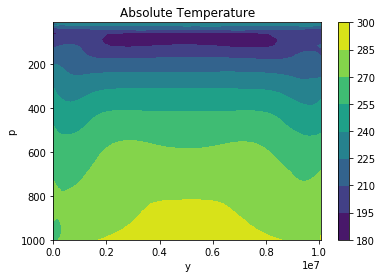

```python
plt.contourf(tm.y, p, tm)
plt.ylim([1000,10])
plt.colorbar()
plt.title("Absolute Temperature")
plt.xlabel("y")
plt.ylabel("p");
```

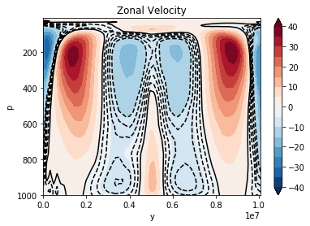

```python
plot_zonal_velocity(mean.U)
```

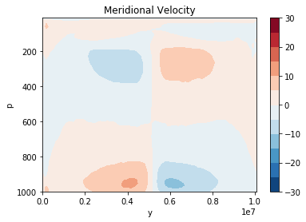

```python
im = plt.contourf(mean.y, mean.p, mean.V, cmap='RdBu_r',
                  levels=np.r_[-30:35:5])

plt.ylim([1000,10])
plt.colorbar(im)
plt.title("Meridional Velocity")
plt.xlabel("y")
plt.ylabel("p");
```

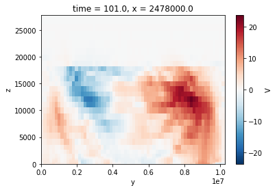

```python
ic = xr.open_dataset("../NGAqua/ic.nc")
ic.V[:,:,15].plot()
```

# Spin-up

Now I plot the temporal evolution of some different fields at a lower atmosphere height as the simulation spins up

Here is the zonal velocity

```
<xarray.plot.facetgrid.FacetGrid at 0x3161d3c50>
```

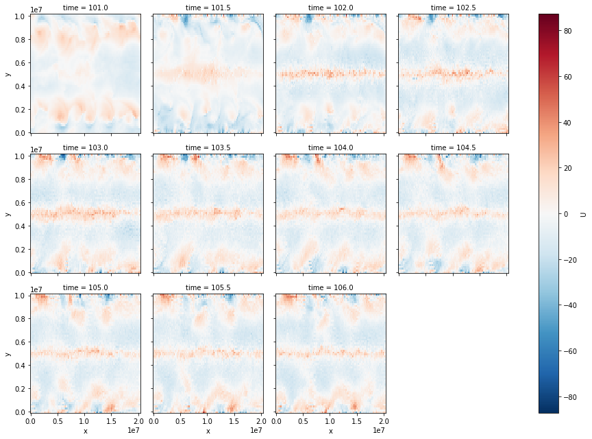

```python
d3.U[::4, 5].plot(col='time', col_wrap=4)
```

and the meridional velocity

```
<xarray.plot.facetgrid.FacetGrid at 0x322a5eda0>
```

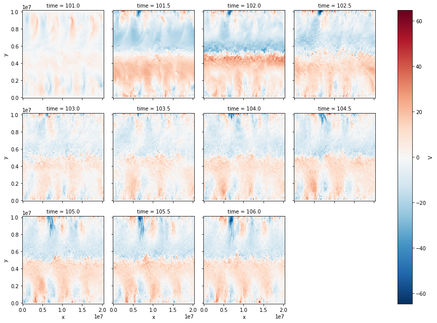

```python
d3.V[::4, 5].plot(col='time', col_wrap=4)
```

and the absolute temperature

```
<xarray.plot.facetgrid.FacetGrid at 0x3235515f8>
```

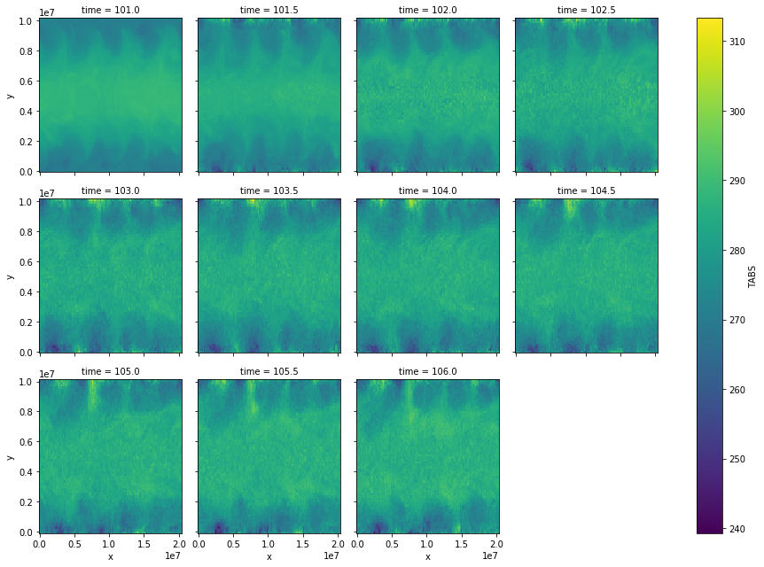

```python
d3.TABS[::4, 10].plot(col='time', col_wrap=4)
```

# What happens if I turn off all physics?

```python
d3 = open_caseid_3d("NGAqua_dt30.noPhys")
```

```
<xarray.plot.facetgrid.FacetGrid at 0x316156eb8>
```

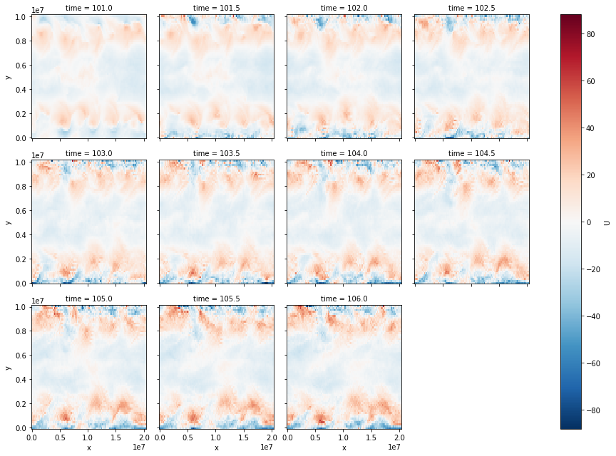

```python
d3.U[::4,5].plot(col='time', col_wrap=4)
```

```
<xarray.plot.facetgrid.FacetGrid at 0x3252e6748>
```

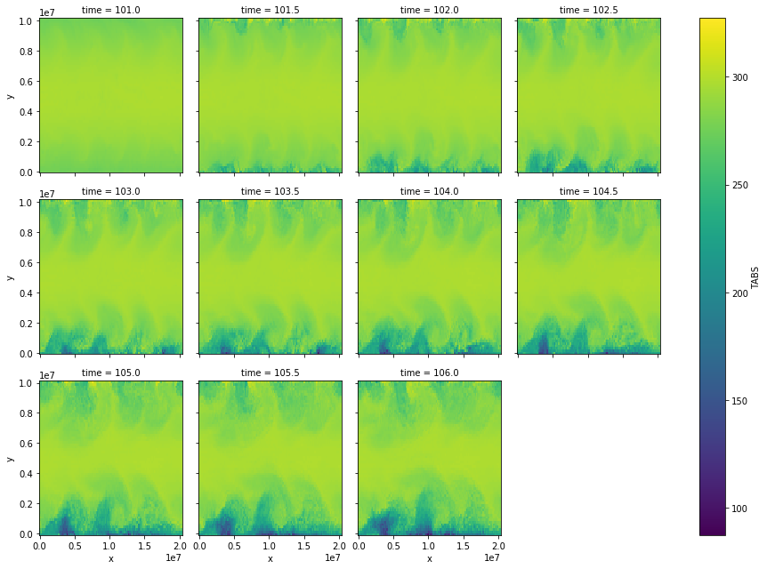

```python
d3.TABS[::4,2].plot(col='time', col_wrap=4)
```

This issue with the boundaries is also present in the noPhys run.

Chris thinks this issue might be due to the staggering of the meridional velocity field. This problem can be diagnosed by seeing how much the velocity field changes after a very small time step.

```python
def test_dataset(caseid):
    paths = [f"../OUT_3D/{caseid}_1_0000000000.nc",
             f"../OUT_3D/{caseid}_1_0000000001.nc"]
    return xr.open_mfdataset(paths, concat_dim='time').assign_coords(time=[0,1])

ds = test_dataset("NGAqua_test.ic")
```

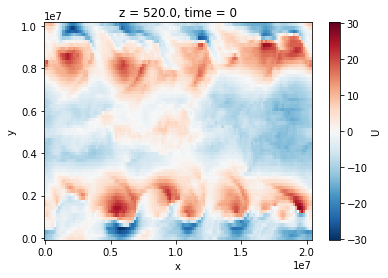

```python
ds.U[0,5].plot()
```

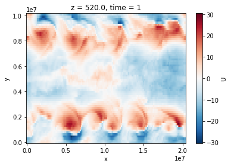

```python
ds.U[1,5].plot()
```

The zonal velocity looks pretty similar after this number of steps, so let's now look at the meridional velocity equation.

```python
def plot_v_slice(ds):

    ds.V[0,5,:,0].plot(label='T0', marker='.')
    ds.V[1,5,:,0].plot(label='T1', marker='o', alpha=.5)

    plt.legend()
```

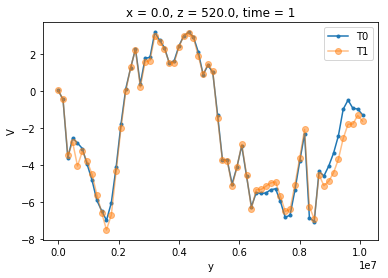

```python
plot_v_slice(ds)
```

As we can see there is a big discrepency in the northern part of the domain after a single 1e-8 second time step. This implies that we should check the velocity staggering. What is the velocity at the southern and northern boundaries?

```
<xarray.plot.facetgrid.FacetGrid at 0x3266c4208>
```

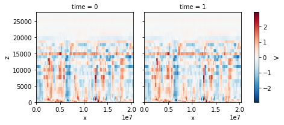

```python
ds.V.isel(y=0).plot(col='time')
```

```
<xarray.plot.facetgrid.FacetGrid at 0x3269eb278>
```

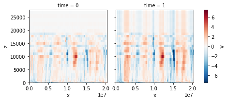

```python
ds.V.isel(y=-1).plot(col='time')
```

# Interface initial conditions

The meridional velocity at the northern boundary is much larger than at the southern boundary. I need to be careful about the staggering of these variables. Instead, let's initialize the model with the data averaged along the interfaces.

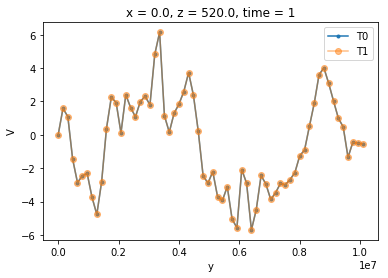

```python
ds_stag = test_dataset("NGAqua_test.ic.staggered")
plot_v_slice(ds_stag)
```

We can see that the V velocity is essentially unchanged by the pressure projection.

```python
np.abs(ds_stag.diff('time')).mean().load()
```

```
<xarray.Dataset>
Dimensions:  ()
Data variables:
    p        float32 1.1269501
    U        float32 6.26996e-05
    V        float32 0.00056423486
    W        float32 0.00017914013
    PP       float32 876930200.0
    TABS     float32 0.4321329
    QV       float32 0.0
```

More quantitiavely, we can see that the MAD of the velocities from between the time steps is very small. Therefore, we should initialize the model with the data from the interfaces. Let's now try, running a dry dynamics simulation with this new initial condition for longer.

```python
ds = open_caseid_3d("NGAqua_icStag.dt30").pipe(swap_z_for_pres)
```

```
<xarray.plot.facetgrid.FacetGrid at 0x325e6f7f0>
```

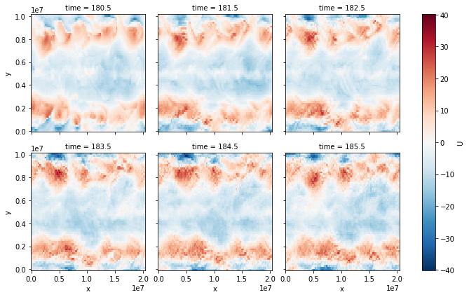

```python
ds.U[::8,5].plot(col='time', col_wrap=3)
```

```
<xarray.plot.facetgrid.FacetGrid at 0x32845f320>
```

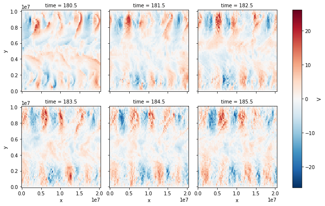

```python
ds.V[::8,5].plot(col='time', col_wrap=3)
```

```
<xarray.plot.facetgrid.FacetGrid at 0x328a7b278>
```

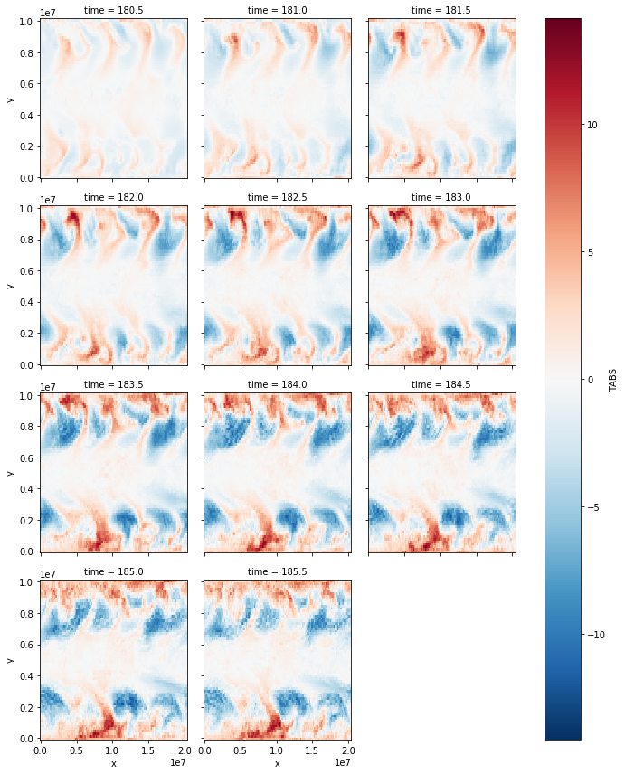

```python
v = 'TABS'

anom = ds[v] - ds[v][0].mean('x')
anom[::4, 5].plot(col='time', col_wrap=3)
```

The simulations are much improved near the boundaries, but the data develops a **grainy appearance** after a few days. I would expect it to get smoother as time progesses since this is a coarse resolution model. Is this caused by the SGS scheme or some other problem? Is the initial data too rough somehow? Is it related to the north/south boundary conditions?

## With SGS

```python
ds = open_caseid_3d('NGAqua_icStag.SGS.dt30')
```

```
<xarray.plot.facetgrid.FacetGrid at 0x328206a90>
```

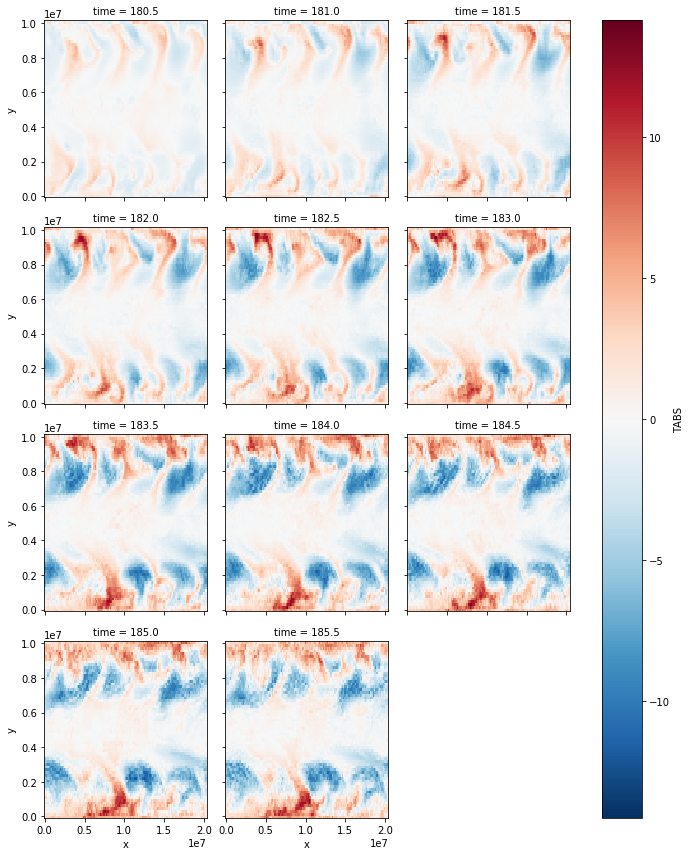

```python
v = 'TABS'

anom = ds[v] - ds[v][0].mean('x')
anom[::4, 5].plot(col='time', col_wrap=3)
```

This looks exactly the same. maybe there is some mistake.

## With Microphysics, Radiation, etc

Now, lets turn on the rest of the physics packages in SAM, and see what the solutions looks like.

```python
ds = open_caseid_3d('NGAqua_icStag.SGS.MICRO.RAD.dt30')
```

```
<xarray.plot.facetgrid.FacetGrid at 0x32b8a6048>
```

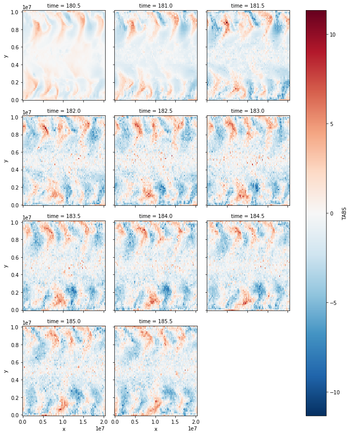

```python
v = 'TABS'

anom = ds[v] - ds[v][0].mean('x')
anom[::4, 5].plot(col='time', col_wrap=3)
```